# 3 - Inferenced for difference in two parameters

In this chapter you’ll extend what you have learned so far to use both simulation and CLT based techniques for inference on the difference between two parameters from two independent numerical distributions.

```r
library(tidyverse)
library(magrittr)
library(ggplot2)
library(infer)
library(openintro)
```

```r
stem_cell
```

[output not shown]

[output cut: 8 more lines]

# Hypothesis testing for comparing two means

## Evaluating the effectiveness of steam cell treatment

Now that we set out hypotheses, we can calculate the observed difference in means between the treatment and control groups. The stem.cell data frame gives us the pumping capacity of the heart before and after the experiment. So first we need to find the difference between these for each experimental unit, and then use these change values to calculate the observed difference in mean change between treatment and control groups.

```r
stem_cell %<>%
  mutate(change = after - before)

stem_cell
```

| trmt | before | after | change |
| --- | --- | --- | --- |
| ctrl | 35.25 | 29.50 | -5.75 |
| ctrl | 36.50 | 29.50 | -7.00 |
| ctrl | 39.75 | 36.25 | -3.50 |
| ctrl | 39.75 | 38.00 | -1.75 |
| ctrl | 41.75 | 37.50 | -4.25 |
| ctrl | 45.00 | 42.75 | -2.25 |
| ctrl | 47.00 | 39.00 | -8.00 |
| ctrl | 52.00 | 45.25 | -6.75 |
| ctrl | 52.00 | 52.25 | 0.25 |
| esc | 29.00 | 31.00 | 2.00 |

[output cut: 8 more lines]

```r
diff_mean <- stem_cell %>%
  group_by(trmt) %>%
  summarize(mean_change = mean(change)) %>%
  pull %>%
  diff

diff_mean
```

```
[1] 7.833333
```

## Evaluating the effectiveness of steam cell treatment (cont.)

```r
n_replicates <- 1000

diff_mean_ht <- stem_cell %>%
  specify(change ~ trmt) %>%
  hypothesize(null = "independence") %>%
  generate(reps = n_replicates, type = "permute") %>%
  calculate(stat = "diff in means", order = c("esc", "ctrl"))

diff_mean_ht
```

```
Response: change (numeric)
Explanatory: trmt (factor)
Null Hypothesis: independence
```

| replicate | stat |
| --- | --- |
| 1 | 1.66666667 |
| 2 | -0.72222222 |
| 3 | 0.50000000 |
| 4 | 1.11111111 |
| 5 | 2.22222222 |
| 6 | -4.27777778 |
| 7 | -3.00000000 |
| 8 | 1.33333333 |
| 9 | -0.11111111 |
| 10 | -3.88888889 |

[output cut: 990 more lines]

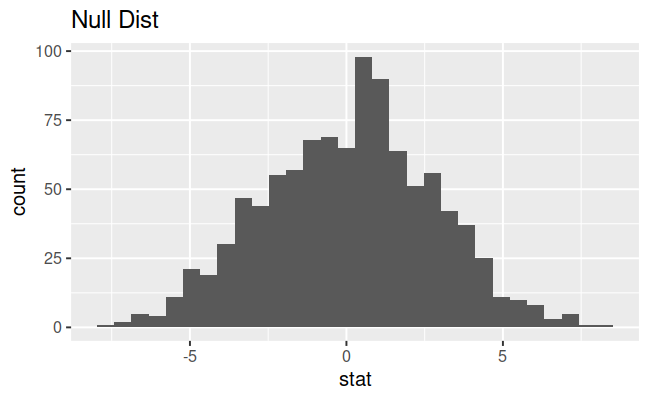

```r
ggplot(diff_mean_ht, aes(x = stat)) +
  geom_histogram() +
  ggtitle("Null Dist")
```

```r
diff_mean_ht %>%
  filter(stat > diff_mean) %>%
  # Calculate p-value
  summarize(p_val = n()/n_replicates)
```

| p_val |
| --- |
| 0.001 |

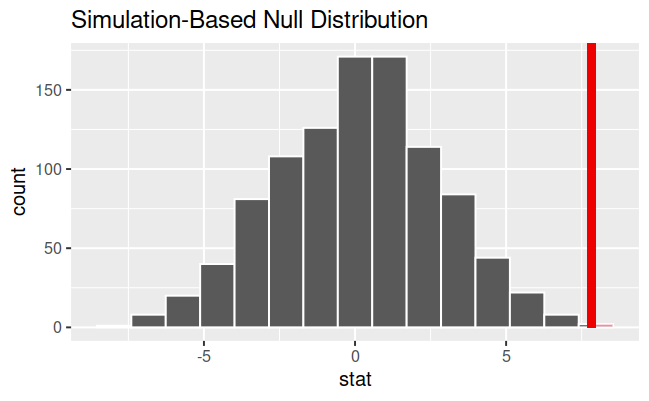

```r
diff_mean_ht %>%
  visualise() +
  shade_p_value(obs_stat = diff_mean, direction = "greater")
```

```r
diff_mean_ht %>%
  get_p_value(obs_stat = diff_mean, direction = "greater")
```

| p_value |
| --- |
| 0.001 |

## Conclusion of the hypothesis test

- The data provide convincing evidence of a difference

## Evaluating the relationship between smoking during pregnancy and birth weight

The state of North Carolina released to the public a large data set containing information on births recorded in this state. This data set has been of interest to medical researchers who are studying the relation between habits and practices of expectant mothers and the birth of their children. ncbirths is a random sample of 1000 cases from this data set. We want to evaluate whether there is a difference between weights of babies born to smoker and non-smoker mothers.

```r
(ncbirths_complete_habit <- ncbirths %>% filter(!is.na(habit)))
```

| fage | mage | mature | weeks | premie | visits | marital | gained | weight | lowbirthweight | gender | habit | whitemom |
| --- | --- | --- | --- | --- | --- | --- | --- | --- | --- | --- | --- | --- |
| NA | 13 | younger mom | 39 | full term | 10 | not married | 38 | 7.63 | not low | male | nonsmoker | not white |
| NA | 14 | younger mom | 42 | full term | 15 | not married | 20 | 7.88 | not low | male | nonsmoker | not white |
| 19 | 15 | younger mom | 37 | full term | 11 | not married | 38 | 6.63 | not low | female | nonsmoker | white |
| 21 | 15 | younger mom | 41 | full term | 6 | not married | 34 | 8.00 | not low | male | nonsmoker | white |
| NA | 15 | younger mom | 39 | full term | 9 | not married | 27 | 6.38 | not low | female | nonsmoker | not white |
| NA | 15 | younger mom | 38 | full term | 19 | not married | 22 | 5.38 | low | male | nonsmoker | not white |
| 18 | 15 | younger mom | 37 | full term | 12 | not married | 76 | 8.44 | not low | male | nonsmoker | not white |
| 17 | 15 | younger mom | 35 | premie | 5 | not married | 15 | 4.69 | low | male | nonsmoker | not white |
| NA | 16 | younger mom | 38 | full term | 9 | not married | NA | 8.81 | not low | male | nonsmoker | white |
| 20 | 16 | younger mom | 37 | full term | 13 | not married | 52 | 6.94 | not low | female | nonsmoker | white |

[output cut: 989 more lines]

```r
# Calculate observed difference in means

diff_mean_obs <- ncbirths_complete_habit %>%
  group_by(habit) %>%
  summarize(mean_weight = mean(weight)) %>%
  pull %>%
  diff

diff_mean_obs
```

```
[1] -0.3155425
```

```r
n_replicates <- 1000

# Generate 1000 differences in means via randomization
diff_mean_ht <- ncbirths_complete_habit %>%
  # Specify weight vs. habit
  specify(weight ~ habit) %>%
  # Null = no difference between means
  hypothesize("independence") %>%
  # Shuffle labels 1000 times
  generate(reps = n_replicates, type = "permute") %>%
  # Calculate test statistic, nonsmoker then smoker
  calculate("diff in means", order = c("nonsmoker", "smoker"))

diff_mean_ht
```

```
Response: weight (numeric)
Explanatory: habit (factor)
Null Hypothesis: independence
```

| replicate | stat |
| --- | --- |
| 1 | -0.3182891507 |
| 2 | -0.0872434953 |
| 3 | -0.1193028964 |
| 4 | 0.2850270005 |
| 5 | -0.0243053510 |
| 6 | 0.1932081492 |
| 7 | -0.1554491900 |
| 8 | 0.0193789887 |
| 9 | -0.1712518409 |
| 10 | -0.1333799705 |

[output cut: 990 more lines]

```r
# Calculate p-value
diff_mean_ht %>%
  # Identify simulated test statistics at least as extreme as observed
  filter(stat < diff_mean_obs) %>%
  # Calculate p-value
  summarize(
    one_sided_p_val = n()/n_replicates,
    two_sided_p_val = 2*one_sided_p_val
  )
```

| one_sided_p_val | two_sided_p_val |
| --- | --- |
| 0.01 | 0.02 |

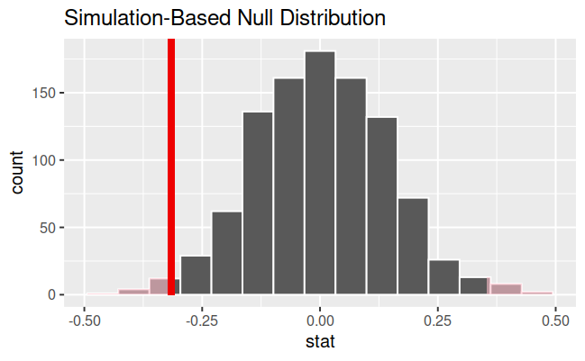

```r
diff_mean_ht %>%
  visualise() +
  shade_p_value(obs_stat = diff_mean_obs, direction = "two sided")
```

```r
diff_mean_ht %>%
  get_p_value(obs_stat = diff_mean_obs, direction = "two sided")
```

| p_value |
| --- |
| 0.02 |

# Bootstrap CI for difference in two means

## Quantifing the relationship between smoking during pregnancy and birth weight

Let’s construct a bootstrap interval for the difference in mean weights of babies born to smoker and non-smoker mothers. The ncbirths_complete_habit data frame you created earlier is available to use.

```r
# Generate 1500 bootstrap difference in means
diff_mean_ci <- ncbirths_complete_habit %>%
  # Specify weight vs. habit
  specify(weight ~ habit) %>%
  # Generate 1500 bootstrap replicates
  generate(reps = 1500, type = "bootstrap" ) %>%
  # Calculate the difference in means, nonsmoker then smoker
  calculate(stat = "diff in means", order = c("nonsmoker", "smoker"))

diff_mean_ci
```

```
Response: weight (numeric)
Explanatory: habit (factor)
```

| replicate | stat |
| --- | --- |
| 1 | 0.426637109 |
| 2 | 0.378756944 |
| 3 | 0.589682372 |
| 4 | 0.163136438 |
| 5 | 0.186797782 |
| 6 | 0.349943865 |
| 7 | 0.149374731 |
| 8 | -0.081522732 |
| 9 | 0.286958086 |
| 10 | 0.208889757 |

[output cut: 990 more lines]

```r
# Calculate the 95% CI via percentile method
diff_mean_ci %>%
  summarize(
    l = quantile(stat, 0.025),
    u = quantile(stat, 0.975)
  )
```

| l | u |
| --- | --- |
| 0.05959137 | 0.5754543 |

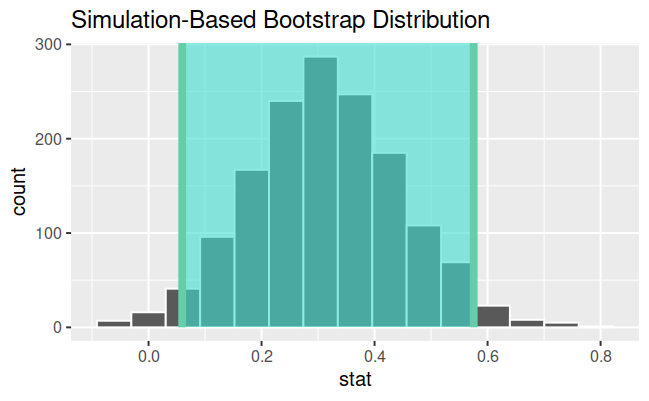

```r
ci <- diff_mean_ci %>%
          get_confidence_interval(level = .95,
                                  type = "percentile")

diff_mean_ci %>%
  visualize() +
  shade_confidence_interval(ci)
```

## Median lenghts of pregnancies for smoking and non-smoking mothers

Let’s turn our attention to another variable, weeks, indicating the length of the pregnancy. Construct a bootstrap interval for the difference in median lengths of pregnancies of smoker and non-smoker mothers.

```r
ncbirths_complete_habit_weeks <- ncbirths %>%
  filter(!is.na(habit)) %>%
  filter(!is.na(weeks))
```

```r
# Generate 1500 bootstrap difference in medians
diff_med_ci <- ncbirths_complete_habit_weeks %>%
  specify(weeks ~ habit) %>%
  generate(reps = 1500, type = "bootstrap") %>%
  calculate(stat = "diff in medians", order = c("nonsmoker", "smoker"))
```

```r
diff_med_ci %>%
  summarize(
    l = quantile(stat, 0.04),
    u = quantile(stat, 0.96)
  )
```

| l | u |
| --- | --- |
| 0 | 1 |

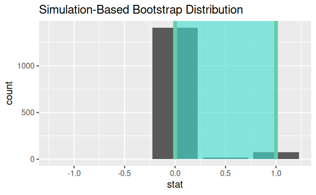

```r
ci <- diff_med_ci %>%
          get_confidence_interval(level = .92,
                                  type = "percentile")

diff_med_ci %>%
  visualize() +
  shade_confidence_interval(ci)
```

# Comparing means with a t-test

## Hourly pay vs. citizenship status

Using the acs12 data, and specifically the variables income, hrs_work, and citizen, summarize, visualize, and compare the distributions of hourly pay rate for citizens and non-citizens.

```r
acs12 %<>%
  mutate(hrly_pay= income / (hrs_work * 52))
```

```r
acs12_complete_hrlypay_citizen <- acs12 %>%
  filter(!is.na(hrly_pay), !is.na(citizen))

acs12_complete_hrlypay_citizen
```

| income | employment | hrs_work | race | age | gender | citizen | time_to_work | lang | married | edu | disability | birth_qrtr | hrly_pay |
| --- | --- | --- | --- | --- | --- | --- | --- | --- | --- | --- | --- | --- | --- |
| 60000 | not in labor force | 40 | white | 68 | female | yes | NA | english | no | college | no | jul thru sep | 28.8461538 |
| 1700 | employed | 40 | other | 35 | female | yes | 15 | other | yes | hs or lower | yes | jul thru sep | 0.8173077 |
| 45000 | employed | 84 | white | 27 | male | yes | 40 | english | yes | hs or lower | no | oct thru dec | 10.3021978 |
| 8600 | employed | 23 | white | 69 | female | yes | 5 | english | no | hs or lower | no | jul thru sep | 7.1906355 |
| 33500 | employed | 55 | white | 52 | male | yes | 20 | english | yes | hs or lower | no | apr thru jun | 11.7132867 |
| 4000 | employed | 8 | white | 67 | female | yes | 10 | english | yes | hs or lower | no | apr thru jun | 9.6153846 |
| 19000 | employed | 35 | white | 36 | female | yes | 15 | english | yes | college | no | jul thru sep | 10.4395604 |
| 3400 | employed | 25 | white | 40 | male | yes | NA | english | no | hs or lower | yes | jan thru mar | 2.6153846 |
| 1200 | not in labor force | 12 | white | 18 | female | yes | NA | english | no | hs or lower | no | jan thru mar | 1.9230769 |
| 140000 | employed | 40 | white | 35 | female | no | 30 | other | no | hs or lower | no | jan thru mar | 67.3076923 |

[output cut: 949 more lines]

```r
# Get number of rows in full dataset
n_all <- nrow(acs12)

# Get number of rows in filtered dataset
n_non_missing <- nrow(acs12_complete_hrlypay_citizen)

# Calculate number missing
n_missing <- n_all - n_non_missing

# Calculate proportion missing
prop_missing <- n_missing / n_all

# See the result
prop_missing
```

```
[1] 0.5205
```

```r
acs12_complete_hrlypay_citizen %>%
  group_by(citizen) %>%
  summarize(
    x_bar = mean(hrly_pay),
    s = sd(hrly_pay),
    n = n()
  )
```

| citizen | x_bar | s | n |
| --- | --- | --- | --- |
| no | 21.19494 | 34.50285 | 58 |
| yes | 18.52151 | 24.72770 | 901 |

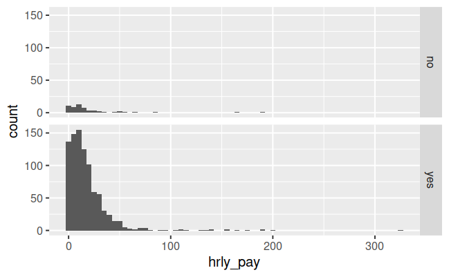

```r
ggplot(acs12_complete_hrlypay_citizen, aes(x = hrly_pay)) +
  geom_histogram(binwidth = 5) +
  facet_grid(rows = vars(citizen))
```

## Estimating the difference of two means using a t-interval

Earlier we used summary statistics and a visualization to compare the hourly pay of citizens vs. non-citizens. In this exercise we estimate the difference between the average hourly pay between these two groups.

The acs12_complete_hrlypay_citizen is already loaded for you.

```r
# Construct 95% CI using a t-test
test_results <- t.test(hrly_pay ~ citizen, data = acs12_complete_hrlypay_citizen)

# See the results
test_results
```

```
    Welch Two Sample t-test

data:  hrly_pay by citizen
t = 0.58058, df = 60.827, p-value = 0.5637
alternative hypothesis: true difference in means between group no and group yes is not equal to 0
95 percent confidence interval:
 -6.53483 11.88170
sample estimates:
 mean in group no mean in group yes
         21.19494          18.52151
```

We can not reyect the null hypothesis.